# Project: Investigate a Dataset (No-Show Appointments)

### Research Question 1 ( Is there a relation between the number of waiting days for an appointment and the 'no-show' rate? )

I will set up masks to filter my DataFrame so i can select the indexes of Appointments who showed /didn't show up.  
showed_up returns pandas series holding indexes and the corosponding truth values, True if it finds no_show Column meeting the condtion in this case " no_show == 'No' " , while the didnt_show_up mask is vise versa.

```python
showed_up = df.no_show == 'No'
didnt_show_up= df.no_show == 'Yes'
```

Now based on these masks i will create another two pandas series to show me how many Appointments showed / Didn't show up for every range of waiting days like so:

```python
plot1=df.waiting_days[showed_up].value_counts().sort_index()
plot2=df.waiting_days[didnt_show_up].value_counts().sort_index()
print(plot1.head())
plot2.head()
```

```
0    36712
1     4063
2     5103
3     2076
4     4046
Name: waiting_days, dtype: int64
```

```
0    1783
1    1099
2    1595
3     635
4    1223
Name: waiting_days, dtype: int64
```

I will also Calculate the sum of waiting days for every day sample for both Appointments which showed up and those which didn't . this will be useful in order to calculate the percentage for each group of waiting days.

```python
total_day=df.waiting_days.value_counts().sort_index()
total_day.head()
```

```
0    38495
1     5162
2     6698
3     2711
4     5269
Name: waiting_days, dtype: int64
```

Now, we can actually see the percentage of Appointments who showed up to the ones which didn't.\ Note that the sum of any percantage for any specific number of waiting days for who showed up and who didn't must be equal to one.\ i.e: 0 days hold 0.953 in the 1st Series and 0.0463 in the 2nd Series , their sum is equal to 1.

```python
plot1_pst=plot1.divide(total_day,fill_value=0)
plot2_pst=plot2.divide(total_day,fill_value=0)
print(plot1_pst.head())
plot2_pst.head()
```

```
0    0.953682
1    0.787098
2    0.761869
3    0.765769
4    0.767888
Name: waiting_days, dtype: float64
```

```
0    0.046318
1    0.212902
2    0.238131
3    0.234231
4    0.232112
Name: waiting_days, dtype: float64
```

#### Now, I will create two sub plots ,the 1st show us the actual number of people who showed / didn't show up related to how large was their waiting days for their appointment. the last one show us the actual percentage for Appointments which showed up to the ones which didn't.

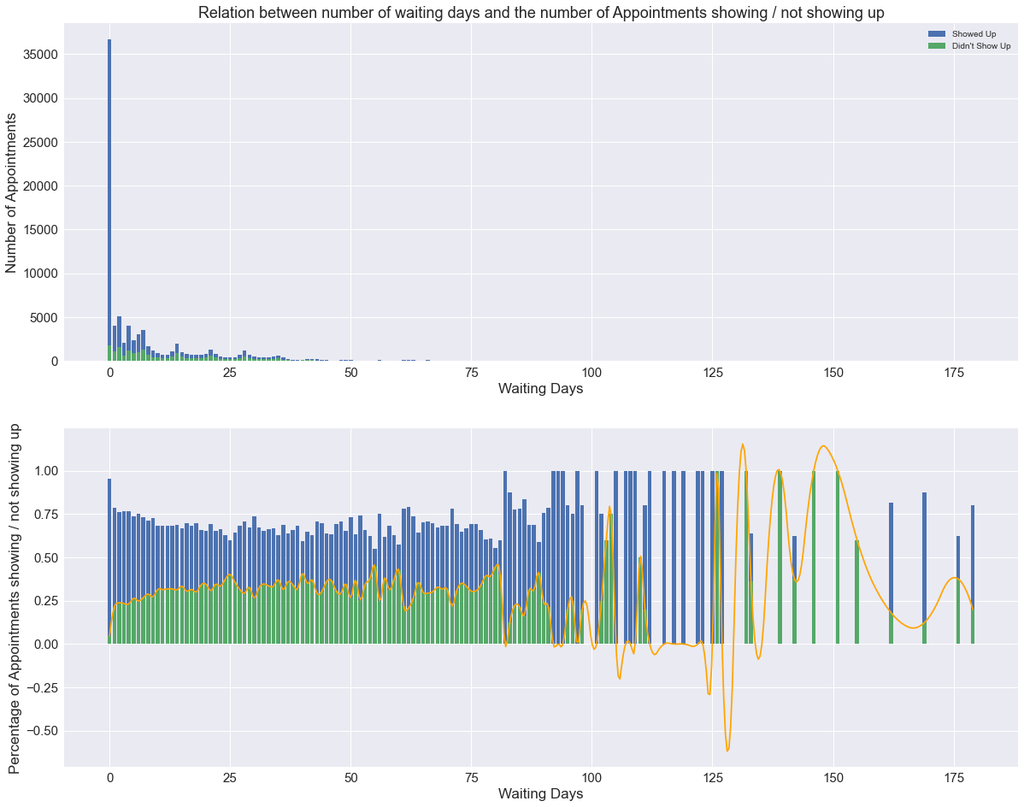

```python
fig1, (ax1, ax2) = plt.subplots(2,1,figsize=(20,16));
ax1.set_title('Relation between number of waiting days and the number of Appointments showing / not showing up' , fontsize=18)
ax1.bar(plot1.index , plot1 ,label='Showed Up');
ax1.bar(plot2.index , plot2, label="Didn't Show Up");
ax1.set_xlabel('Waiting Days',fontsize=17);
ax1.set_ylabel('Number of Appointments',fontsize=17);
ax1.tick_params(labelrotation=0 , labelsize=15);
ax1.legend(loc=1);

ax2.bar(plot1_pst.index , plot1_pst, label='Showed Up');
ax2.bar(plot2_pst.index , plot2_pst, label="Didn't Show Up");
spline(plot2_pst,ax2,500)
ax2.set_xlabel('Waiting Days',fontsize=17);
ax2.set_ylabel('Percentage of Appointments showing / not showing up',fontsize=17);
ax2.tick_params(labelrotation=0,labelsize=15);
```

I will plot the 1st plot again but without "0 days" waiting time to further elaborate the relations.

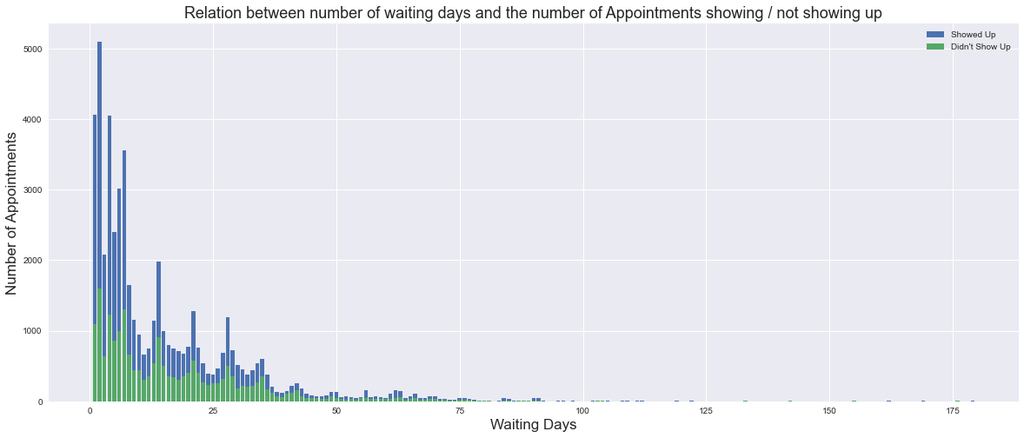

```python
plt.figure(figsize=(20,8));
plt.title('Relation between number of waiting days and the number of Appointments showing / not showing up' , fontsize=18)
plt.bar(plot1.index[1:] , plot1[1:] ,label='Showed Up');
plt.bar(plot2.index[1:] , plot2[1:], label="Didn't Show Up");
plt.xlabel('Waiting Days',fontsize=17);
plt.ylabel('Number of Appointments',fontsize=17);
plt.legend(loc=1);
```

### Q1 Observation & Conclusions:

> > I think that it is safe to say that we can " partially calculate" the percantage of someone not showing up for an appointment based on waiting days if they ask for it during a month period , why a month? , we can see that the 1st plot is skewed to the right , majority of the data samples exist during the 1st month and around 30% of the data is just in the 1st tick "0 days" , so if i would make decision based on a guess , it has to be during the 1st month , now by saying "partially calculate" i mean that there might be other factors influencing "no-shows", not just the waiting days.

### Research Question 2 ( Is there a relation between the age and the 'no-show' rate? )

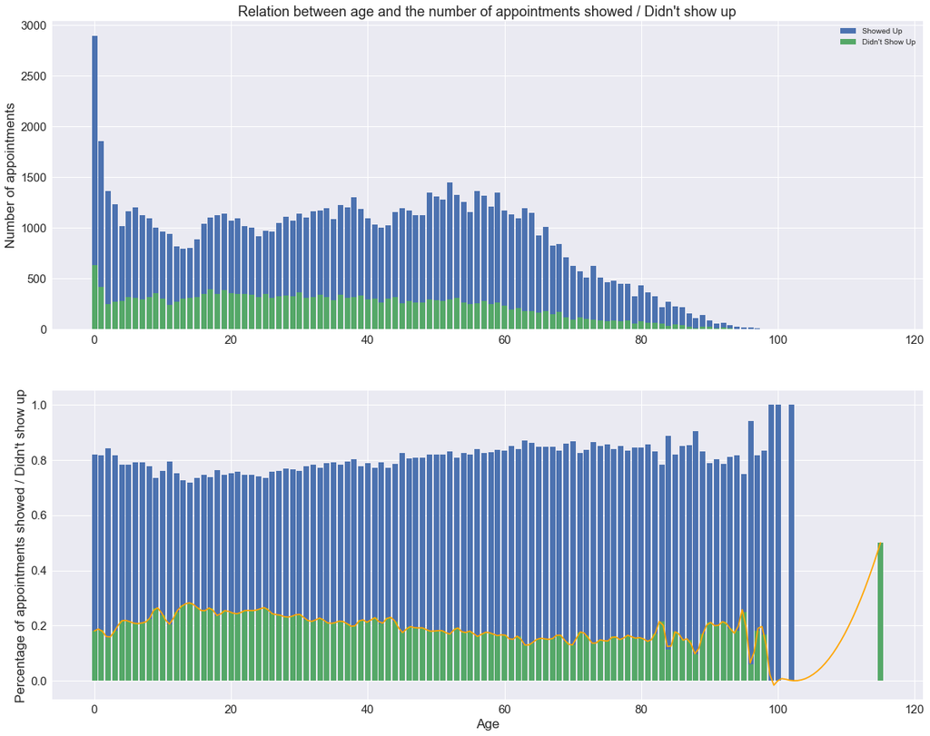

```python
plot3=df.age[showed_up].value_counts()
plot4=df.age[didnt_show_up].value_counts()

total_age=plot3.add(plot4,fill_value=0).astype(int)

plot3_pst=plot3.divide(total_age,fill_value=0)
plot4_pst=plot4.divide(total_age,fill_value=0)

fig2, (ax1, ax2) = plt.subplots(2,1,figsize=(20,16));

ax1.set_title("Relation between age and the number of appointments showed / Didn't show up" , fontsize=18)
ax1.bar(plot3.index , plot3 ,label='Showed Up');
ax1.bar(plot4.index , plot4, label="Didn't Show Up");
ax1.set_ylabel('Number of appointments',fontsize=17);
ax1.tick_params(labelrotation=0 , labelsize=15);
ax1.legend(loc=1);
#ax1.set_xticks(plot1.index)

ax2.bar(plot3_pst.index , plot3_pst, label='Showed Up');
ax2.bar(plot4_pst.index , plot4_pst, label="Didn't Show Up");
spline(plot4_pst,ax2,200)
ax2.set_xlabel('Age',fontsize=17);
ax2.set_ylabel("Percentage of appointments showed / Didn't show up",fontsize=17);
ax2.tick_params(labelrotation=0,labelsize=15);
#ax2.set_xticks(plot1_pst.index)
```

```python
df.groupby('no_show')['age'].mean()
```

```
no_show
No     37.792697
Yes    34.281538
Name: age, dtype: float64
```

### Q2 Observation and Conclusion

> **First plot**: looks like kids that are younger than 1 year old is the maximum count and its around 50% more than the other ages, counts decreases as age increases till around the 14~15 years old mark , then it keeps on increasings till 19~20 years old mark .moving on, the count of 'show up' appointments keeps on increasing till around 55~60 years old , after that less people appointments in every age category.in general, it looks like older people of average 38 years old seem to show up more than who don't with an avarge of 34 years old.  
> **Second plot**: the'no-shows' peaks at 14~15 years old mark with a percentage little less than 30% and its keeps on gradually decreasing all the way till 75~80 years old with 'no-shows' percentage around 19% , this indicates that generally, older people 'no-shows' is less than younger people

### Research Question 3 ( Is there a relation between the neighbourhood and the 'no-show' rate? )

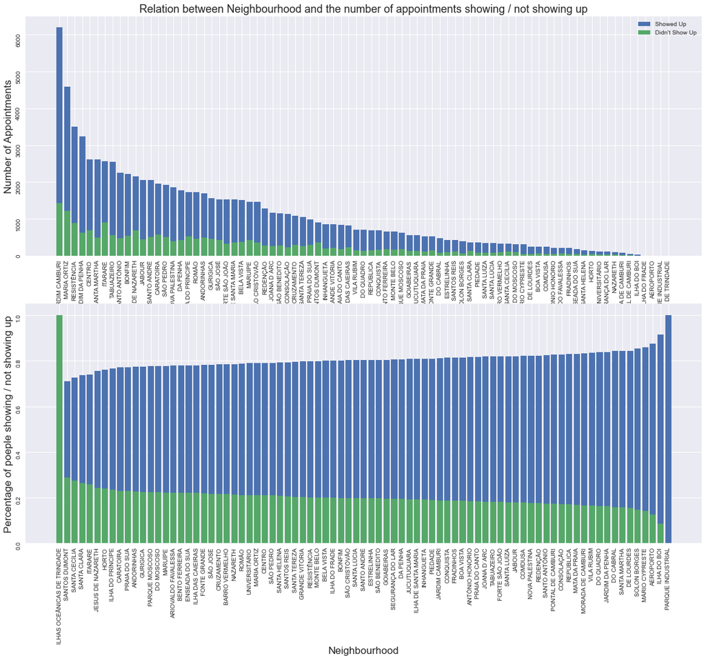

```python
plot5=df.neighbourhood[showed_up].value_counts()
plot6=df.neighbourhood[didnt_show_up].value_counts()

total_hood=plot5.add(plot6,fill_value=0).astype(int)

plot5_pst=plot5.divide(total_hood,fill_value=0).sort_values()
plot6_pst=plot6.divide(total_hood,fill_value=0)

fig3, (ax1, ax2) = plt.subplots(2,1,figsize=(20,16));

ax1.set_title('Relation between Neighbourhood and the number of appointments showing / not showing up' , fontsize=18)
ax1.bar(plot5.index , plot5 ,label='Showed Up');
ax1.bar(plot6.index , plot6, label="Didn't Show Up");
ax1.set_ylabel('Number of Appointments',fontsize=17);
ax1.tick_params(labelrotation=90 , labelsize=10);
ax1.legend(loc=1);
#ax1.set_xticks(plot1.index)

ax2.bar(plot5_pst.index , plot5_pst, label='Showed Up');
ax2.bar(plot6_pst.index , plot6_pst, label="Didn't Show Up");
ax2.set_xlabel('Neighbourhood',fontsize=17);
ax2.set_ylabel('Percentage of poeple showing / not showing up',fontsize=17);
ax2.tick_params(labelrotation=90,labelsize=10);
#ax2.set_xticks(plot1_pst.index)
```

### Q3 Observation and Conclusion

> **First plot**:there are certainly some Neighbourhoods that inquire medical attention more than others, but i can also see that as this number decreases , at some point the 'no-shows' increase.  
> **Second plot**: we can see the percentage of the 'shows' to 'no-shows' for each Neighbourhood , Note that this plot doesnt share the same x-axis with the 1st plot.

### Research Question 4 ( Does the Diabatic Status, Alcoholism, Hypertension, Sending SmS & the Wellfare Program influence the 'no-show' rate? )

```python
total_diabetes=df.diabetes.value_counts()
show_diabetes=df[showed_up].diabetes.value_counts().divide(total_diabetes)
no_show_diabetes=df[didnt_show_up].diabetes.value_counts().divide(total_diabetes)

total_alcoholism=df.alcoholism.value_counts()
show_alcoholism=df[showed_up].alcoholism.value_counts().divide(total_alcoholism)
no_show_alcoholism=df[didnt_show_up].alcoholism.value_counts().divide(total_alcoholism)

total_hipertension=df.hipertension.value_counts()
show_hipertension=df[showed_up].hipertension.value_counts().divide(total_hipertension)
no_show_hipertension=df[didnt_show_up].hipertension.value_counts().divide(total_hipertension)

total_sms_received=df.sms_received.value_counts()
show_sms_received=df[showed_up].sms_received.value_counts().divide(total_sms_received)
no_show_sms_received=df[didnt_show_up].sms_received.value_counts().divide(total_sms_received)

total_scholarship=df.scholarship.value_counts()
show_scholarship=df[showed_up].scholarship.value_counts().divide(total_scholarship)
no_show_scholarship=df[didnt_show_up].scholarship.value_counts().divide(total_scholarship)

shows=show_diabetes.append([show_alcoholism,
                            show_hipertension,
                            show_sms_received,
                            show_scholarship
                            ],ignore_index=True)

no_shows=no_show_diabetes.append([no_show_alcoholism,
                            no_show_hipertension,
                            no_show_sms_received,
                            no_show_scholarship
                            ],ignore_index=True);
```

```python
total_sms_received
df[showed_up].sms_received.value_counts()
```

```
0    62106
1    25698
Name: sms_received, dtype: int64
```

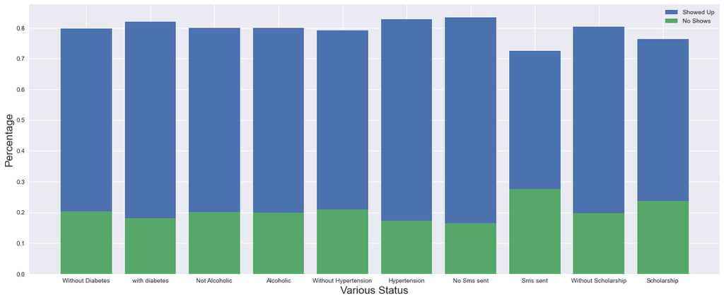

```python
plt.figure(3,figsize=(20,8))
plt.bar(shows.index,shows,label='Showed Up')
plt.bar(no_shows.index,no_shows,label='No Shows')
labels=['Without Diabetes','with diabetes','Not Alcoholic','Alcoholic','Without Hypertension','Hypertension','No Sms sent','Sms sent','Without Scholarship','Scholarship']
plt.xticks(shows.index,labels)
plt.xlabel('Various Status',fontsize=17)
plt.ylabel('Percentage',fontsize=17)
plt.legend();
```

### Q4 Observation and Conclusion

> In the figure the blue bars indicates the % of showed up appointments while the green bars indicates the ones which didn't ,Every two successive columns are strictly indicating the status of patient i.e Not Alcholic & Alcholic.  
> The following section will be relating to the **'no-shows'** only & not the 'shows'  
> **Diabatic Status:** the first two bars indicates that the 'no-shows' is 20% for appointments with healthy people (out of 102,011 appointments) while its only 18% for the ones with diabetes (out of 7,893 appointments).  
> **Alcohol Status:** the second two bars indicates that the 'no-shows' is 21% for appointments with people who don't drink alcholol (out of 106,560, appointments) while its only 19% for appointments with people who don't drink (out of 3,344 appointments).  
> **Hypertension Status:** the third two bars indicates that the 'no-shows' is 20% for appointments with people who dont have hypertension issues (out of 88,226 appointments) while its only 17% for the ones with Hypertension (out of 21,678 appointments).  
> **SmS Status:** the fourth two bars indicates that the 'no-shows' is 16% for appointments with people who were not notified with an SmS (out of 74,422 appointments) and **surprisingly** its 27% for appointments with the people who got notified with one (out of 35,482 appointments), intresting! , we will dig deeper into this, could it be related to Simpson's Paradox?  
> **Welfare Program Status:** the fifth two bars indicates that the 'no-shows' is 19% for appointments with people that has no welfare program (out of 99,102 appointments) while it is 23% for the ones registered in the [Bolsa Família](https://en.wikipedia.org/wiki/Bolsa_Fam%C3%ADlia) (out of 10,802 appointments).

In my interpretation, A better way to actually see why this unexpected result happened with the Sms bars, is to see the population size and distribution for all the following groubs:

- Appointments with 'Sms sent' & 'Show up'
- Appointments with 'Sms sent' & 'No Show'
- Appointments with 'No Sms sent' & 'Show up'
- Appointments with 'No Sms sent' & 'No Show'

```python
recieved_sms=df.sms_received == 1
recieved_no_sms=df.sms_received == 0

sms_noshow=df[(recieved_sms & didnt_show_up)].shape[0]  #9784 appointments who got sms and didn't show (out of 35,482 appointments got sms)
                                                        #9874 /35482 = 27.8%
sms_show=df[(recieved_sms & showed_up)].shape[0]        #25698 appointments who got sms and showed (out of 35,482 appointmenst got sms )
                                                        #25698/35482 = 72.4%

nosms_noshow=df[(recieved_no_sms & didnt_show_up)].shape[0]#12,316 appointments with no sms and didn't show (out of 74,422 appointments got sms)
                                                           #12,316/74,422 = 16.54%
nosms_show=df[(recieved_no_sms & showed_up)].shape[0]      #62,106 appointments with  no sms and showed (out of 74,422 appointmenst got sms )
                                                           #62,106/74,422 =83.45%
```

```python
check =sms_noshow+sms_show+nosms_noshow+nosms_show
check
```

```
109904
```

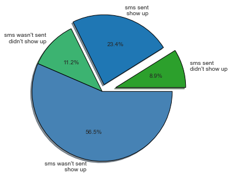

```python
lbl=["sms sent\ndidn't show up","sms sent\n show up","sms wasn't sent\ndidn't show up","sms wasn't sent\nshow up"]
myexplode = [0.2, 0.1, 0, 0]
color=['tab:green','tab:blue','mediumseagreen','steelblue']
plt.pie(x=[sms_noshow , sms_show , nosms_noshow , nosms_show] ,
        labels=lbl ,autopct='%1.1f%%' ,shadow=True ,explode=myexplode, wedgeprops={"edgecolor":"0",'linewidth': 1},
        colors=color);
```

## Conclusions

### Inispiration

Using the data above, we can write a script that calculates the probabilty of someone showing up for an appointment.  
this is done by receiving input form the patient from the following questions, for example:

- how old is he/she?
- which neighbourhood does he/she want to take the appointment?
- does he/she suffer from hypertension?
- does he/she suffer from diabetes?
- does he/she drink alcohol ?
- when would he/she like to come for an appointment?

Based on these answers, we would take each individual input and look up the percentage for an appointment not to show up in every single category from the pervious statistics that we calculated, for example:

- CHECK THE CODE CELL BELOW.
- Adam is **23** years old, this means he has a 25.3% chance not to show up based on his age.
- Adam wants an appointment **7 days** from now , this means he has a 26% chance not to show up based on his waiting days.
- Adam is **not suffering** from hypertension, this means he has 20.8% chance not show up based on his Hypertension status.  
  ................ and so on.

```python
print(plot4_pst[23])
print(plot2_pst[7])
print(no_show_hipertension[0])
```

```
0.2537202380952381
0.2671740024681201
0.20821526534128262
```

From this point onward, we can count only the max percentage for him, or take a weighted mean, personally i would count only the max percentage.

### Limitations

One thing that i found to be strange , the fact that majority of data samples comes from scheduel day after march 2016, with earliest record at november 2015, this is a 5 months difference and thats huge , during this period there are 402 appointments only, why there wasn't more appointments during this period, i find it also weird that after march 2016 it shows significant growth for appointments. was the selection process for the sample biased?, if so this could mean that calculations above are insignificant and could be wrong.